# Plots for Mayra

# Data visualization

First, we plot a hierarchical clustering of the data according to the raw estimated number of counts. The plot shows that batches a, b/c, and d have huge differences between them, which cause the batch effect to be much more prevalent than either the treatment or time effect. In particular, batch a seems much further than the others, while batch d seems fairly close to b/c. Batch d contains only samples after 48 hours, so differences between it and b/c are unsurprising.

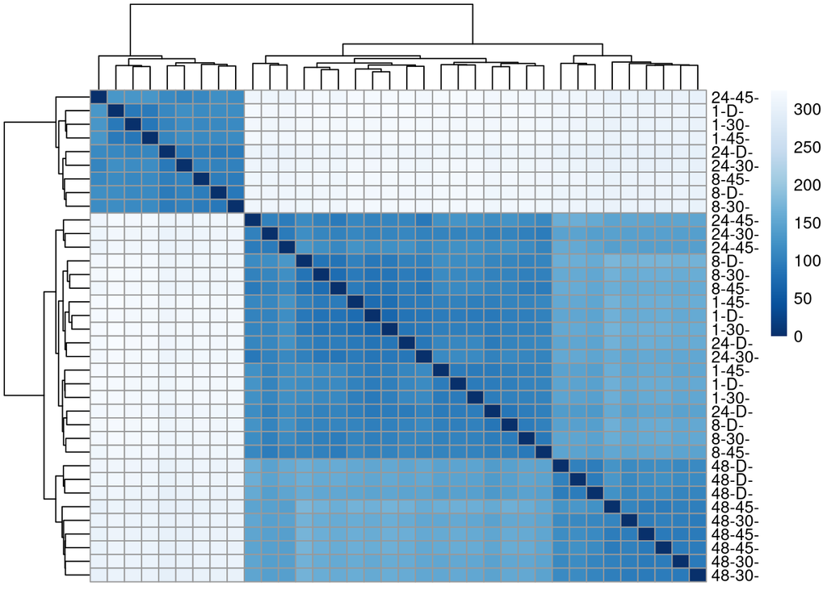

A PCA plot supports this notion. This one seems to suggest that the vast majority of variance in the data can be attributed to variation between batch a, and the others. After that, the next largest contributor to variance seems to be differentiating between groups b/c and d, and, finally, between b and c.

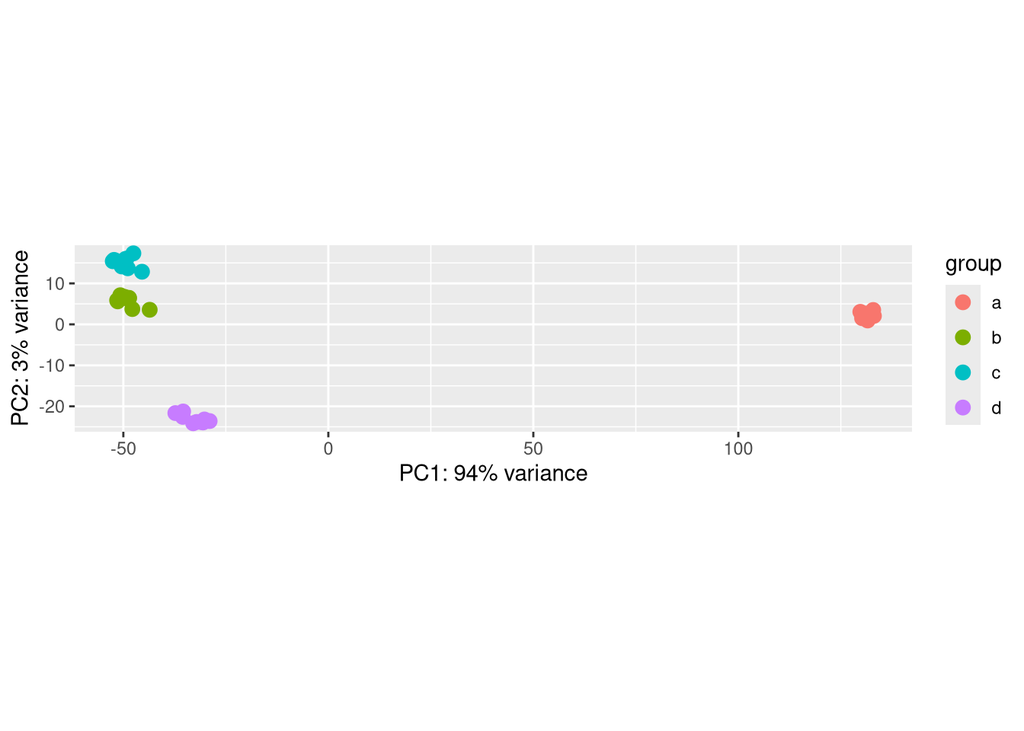

After normalizing, we model our data as
$$\log_2y_{gitjk} = \mu_g + {\rm Treatment}_{gi} + {\rm Time}_{gt} +
{\rm TreatmentTime}_{git} + {\rm BatchA}_{gj} + \varepsilon_{gitjk},$$
a linear model with an interaction between time and treatment, which includes a batch effect for batch A to account for varying levels of gene $g$ in DMSO after 1 hour in the batch A group compared to the rest. The null model is set as
$$\log_2y_{gitjk} = \mu_g + {\rm Time}_{gt} + {\rm BatchA}_{gj} +
\varepsilon_{gitjk},$$
which still contains the batch adjustment, but now asserts that there is no treatment effect on the log-counts.

For each gene, we conduct a LRT to compare the full model to the reduced, null model, and, from that obtain a $p$-value. Those $p$-values are then adjusted using the Benjamini-Hochberg correction, to obtain an estimated False Discovery Rate. False Discovery Rate cutoff is set at 0.01.

We also extract from that model the MLE of the $\log_2$-fold change between DMSO and IC75 Atovaquone, each at 48 hours, to model the effect size of the treatment. The genes with the lowest FDR are reported here.

|  | log2FoldChange | pvalue | padj |
| --- | --- | --- | --- |
| LDHA | -1.09 | 1.05e-134 | 1.67e-130 |
| KIF20A | -2.38 | 7.93e-85 | 6.28e-81 |
| DLGAP5 | -1.93 | 9.28e-83 | 4.9e-79 |
| HMMR | -2.23 | 3.79e-78 | 1.5e-74 |
| CAPRIN1 | -0.572 | 4.5e-75 | 1.43e-71 |
| IFRD1 | 1.57 | 1.34e-74 | 3.54e-71 |
| CCNB1 | -1.68 | 2.35e-69 | 5.33e-66 |
| AURKA | -2 | 5.61e-69 | 1.11e-65 |
| CEBPG | 1.25 | 2.19e-68 | 3.86e-65 |
| BUB1 | -1.54 | 9.39e-68 | 1.49e-64 |

To further investigate these genes, a heatmap showing the residuals under the null model that the values are dependent only on time is displayed. Each row is a gene (marked on the left, along with the estimated FDR), and each column is a sample. Higher residuals (more red) imply that the genes in that sample are more highly expressed than on average across samples.

Looking at the one-hour columns, we see that there is often little variation between the three treatments. However, DDIT3, in the presence of IC75 atovaquone, does seem to be elevated compared to DMSO after only one hour.

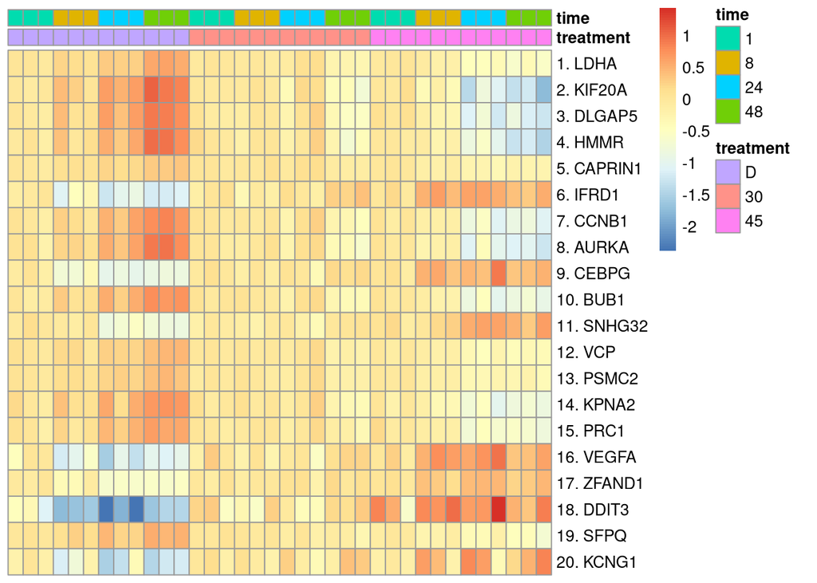

# Gene Set Exploration

## Oxidative stress

This super category is defined by the sub-categories as

```
## $Redox
## [1] "SLC7A11" "CHAC1"   "MTHFD2"  "SOD2"    "SESN2"   "GDF15"   "GADD45A"
## [8] "TXNIP"
##
## $`DNA repair`
## [1] "UNC5B" "DDIT4" "RBBP8" "LONP1"
```

First we plot a heatmap.

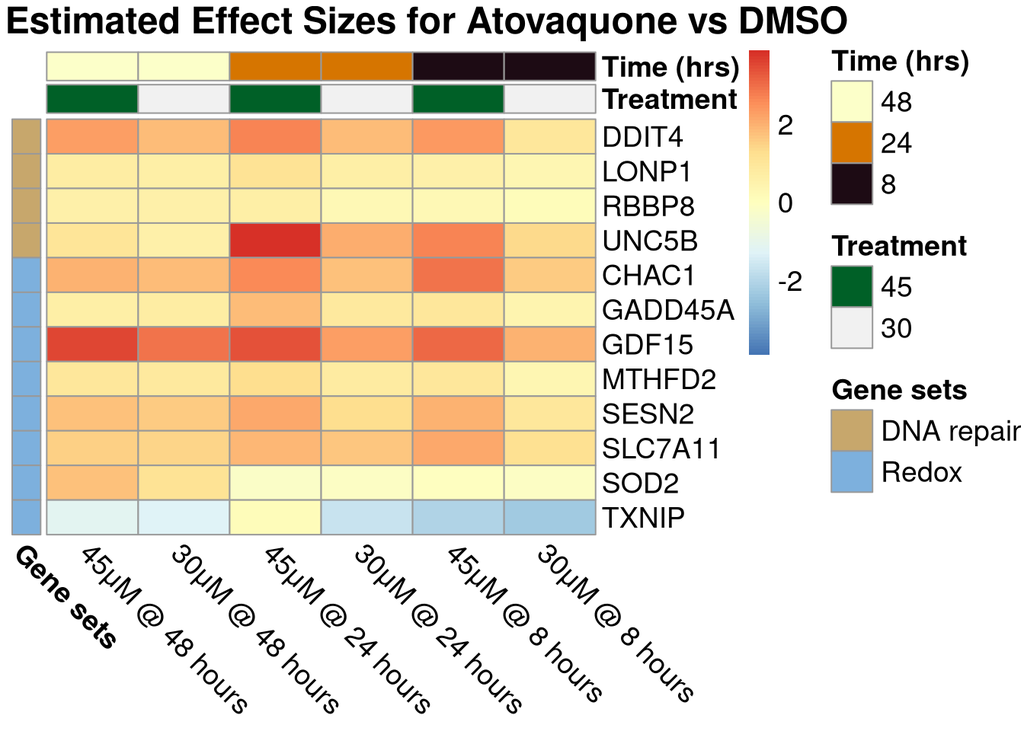

And then a barplot.

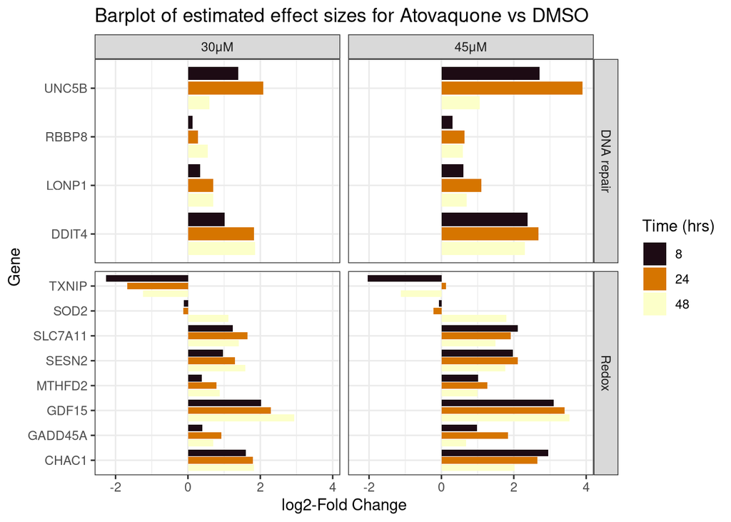

## Cell cycle

This super category is defined by the sub-categories as

```
## $`Mitotic checkpoint`
## [1] "BUB1"  "BUB1B" "BUB3"
##
## $`DNA replication initiation`
## [1] "MCM10" "MCM4"  "MCM7"
```

First we plot a heatmap.

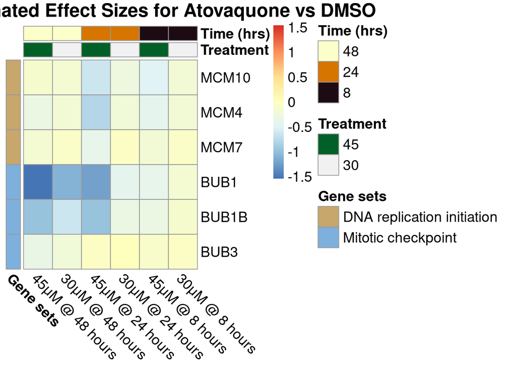

And then a barplot.

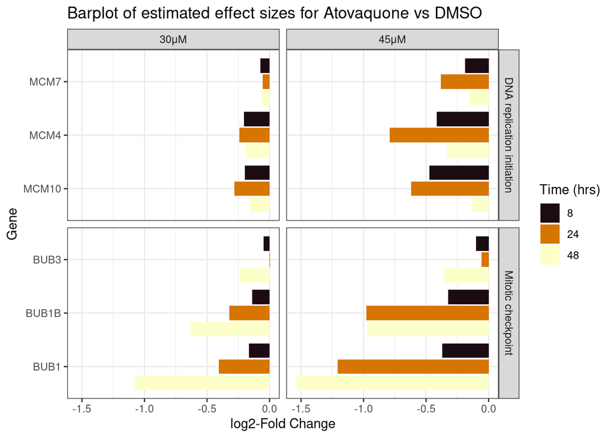

## RNA and protein processing

This super category is defined by the sub-categories as

```
## $Spliceosome
## [1] "DDX23" "DDX24" "DDX3X"
##
## $Proteasome
## [1] "PSMC2"  "PSMD1"  "PSMD12" "PSMD6"  "PSMB2"
##
## $`Ribonucleoprotein complex`
##  [1] "SNRPD3"  "SNRPD1"  "SNRPB2"  "HNRNPH2" "HNRNPM"  "HNRNPF"  "HNRNPDL"
##  [8] "HNRNPR"  "HNRNPU"  "HNRNPD"  "HNRNPA1"
##
## $`Serine and arginine-rich splicing factors`
## [1] "SRSF3"  "SRSF2"  "SRSF11" "SRSF10" "SRSF1"
```

TODO: DDX3X3 was not in the gene list. I replaced it with DDX3X.

First we plot a heatmap.

[figure not shown]

And then a barplot.

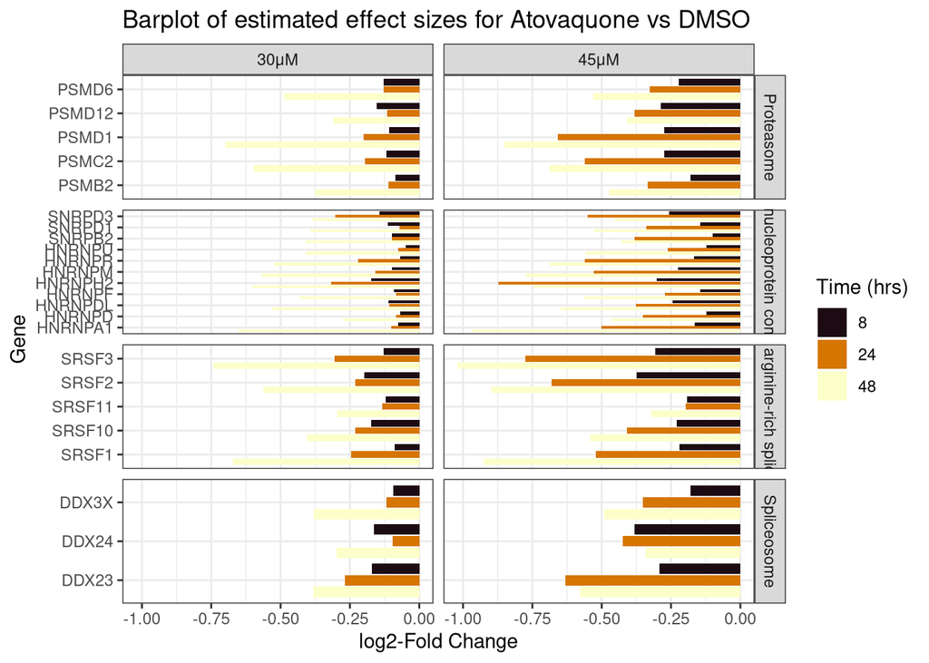

This super category is defined by the genes

```
## $`Glycolysis and pentose phosphate pathway`
## [1] "GPI"   "ALDOA" "G6PD"  "PGLS"
```

First we plot a heatmap.

[figure not shown]

And then a barplot.

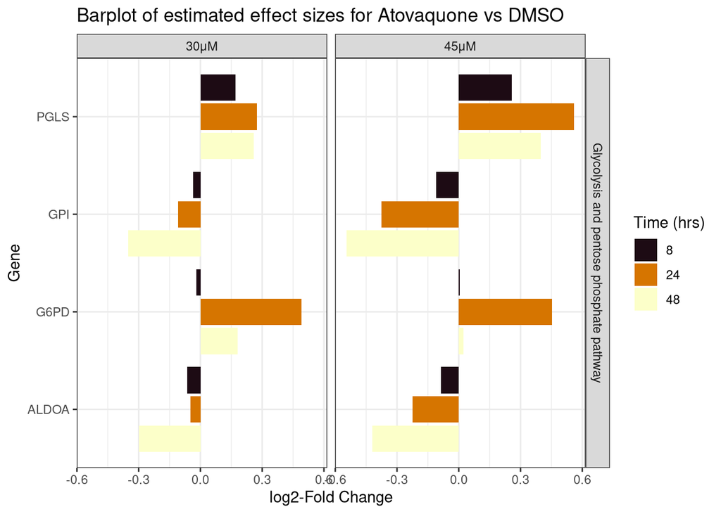

## Folate cycle

This super category is defined by the sub-categories as

```
## $`Folate cycle`
## [1] "ALDH1L2"  "MTHFD2"   "MTHFDL1L" "SHMT2"    "DHFR"
```

First we plot a heatmap.

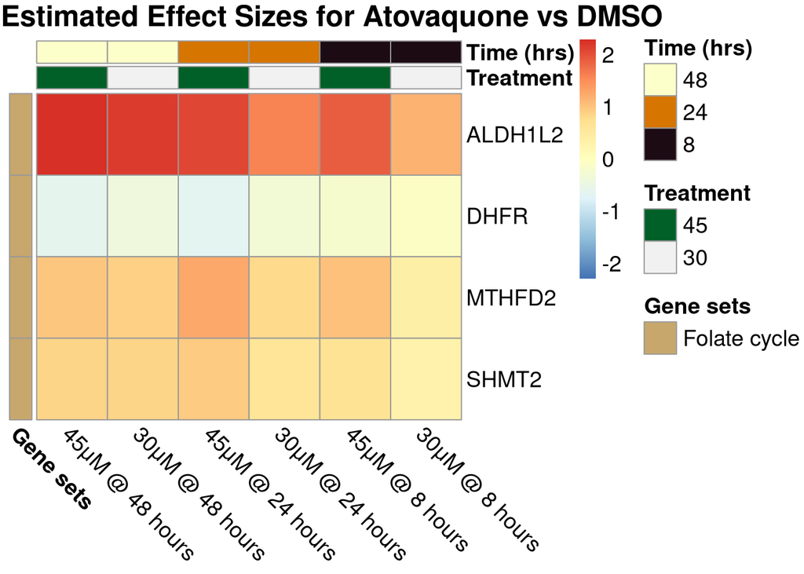

And then a barplot.

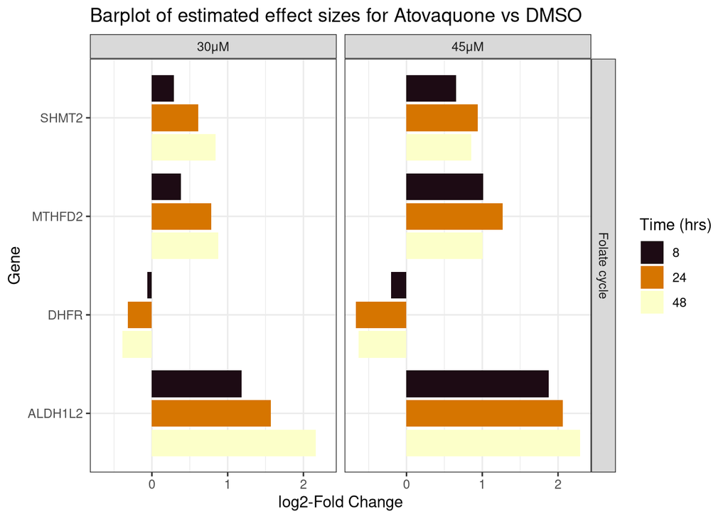

## Glutathione synthesis

This super category is defined by the sub-categories as

```
## $`Glutathione synthesis`
## [1] "GCLC"    "GCLM"    "CTH"     "CBS"     "SLC7A11"
```

First we plot a heatmap.

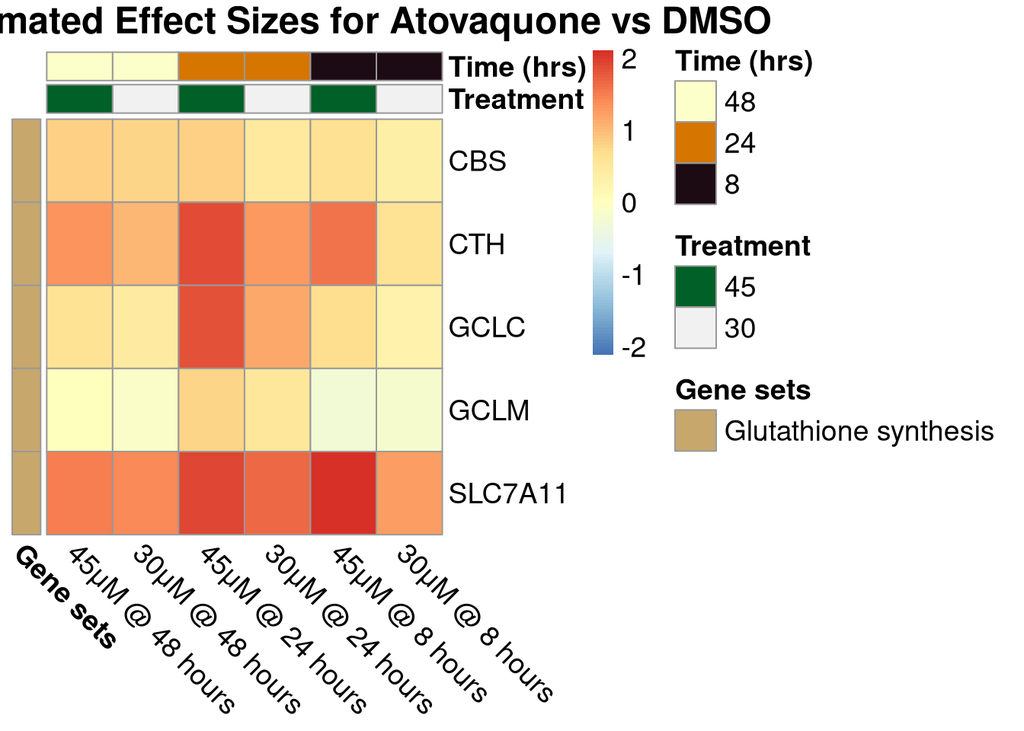

And then a barplot.

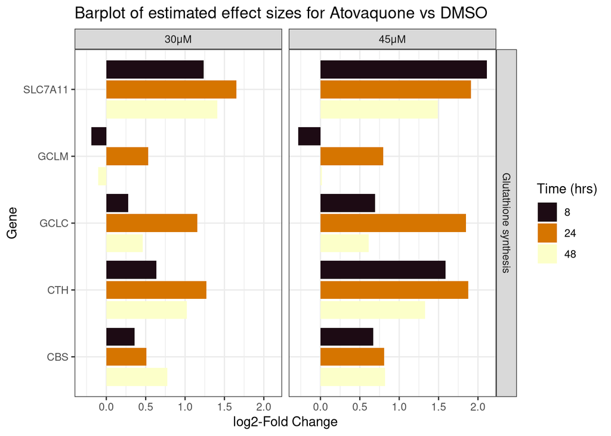

## Protein processing in ER

This super category is defined by the sub-categories as

```
## $`ER chaperones`
## [1] "CALR"      "HSPA1L"    "HSPA8"     "DNAJA1"    "HSPA90AA1" "HSPA90AB1"
## [7] "HSPA90B1"  "HSPH1"
##
## $`Protein processing machinery`
## [1] "SEC61B" "STT3B"  "OSTC"
##
## $`Protein quality control`
## [1] "DAD1"    "UBQLN1"  "UBQLN2"  "SKP1"    "CUL1"    "TRAM1L1"
##
## $`ER-associated protein degradation`
## [1] "GANAB"   "RAD23A"  "SEL1L"   "SEL1L3"  "HERPUD1" "SYVN1"
##
## $`ER quality control`
## [1] "UGGT2"   "DNAJC10" "DNAJC1"  "MOGS"
##
## $`Unfolded protein response`
## [1] "ATF4"  "ATF6"  "ERN1"  "XBP1"  "DDIT3"
```

First we plot a heatmap.

[figure not shown]

And then a barplot.

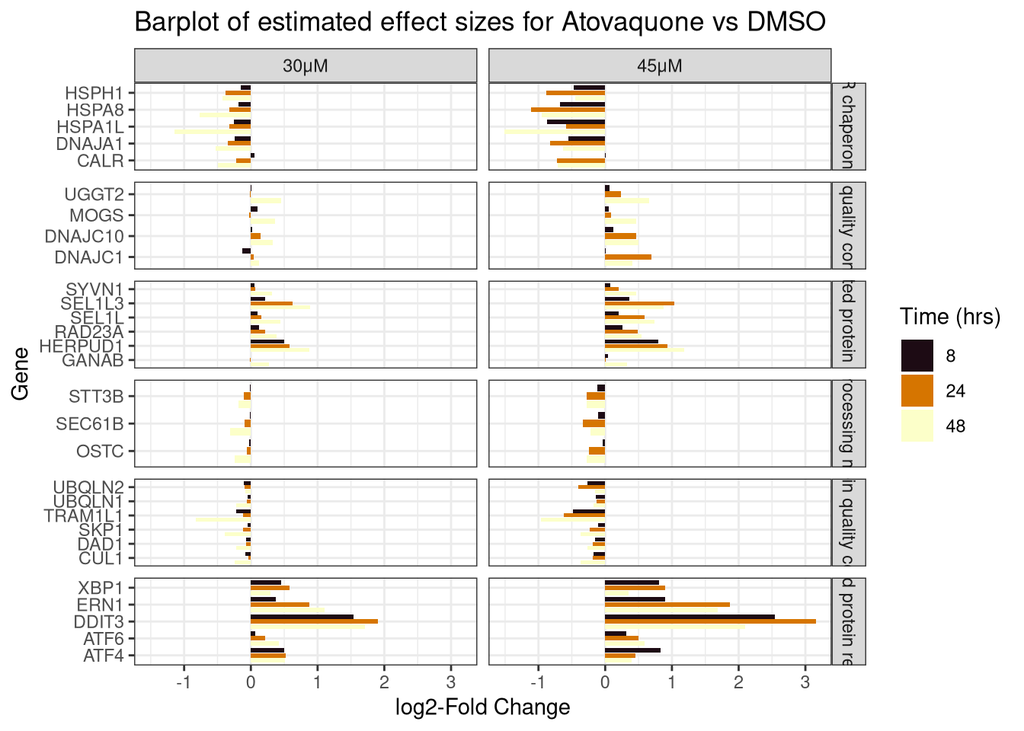

## CHOP-regulated genes

This super category is defined by the sub-categories as

```
## $`CHOP-regulated genes`
## [1] "TRIB3"     "TNFRSF10B" "GADD34"    "KLHDC7B"   "BBC3"      "PMAIP1"
## [7] "HRK"
```

First we plot a heatmap.

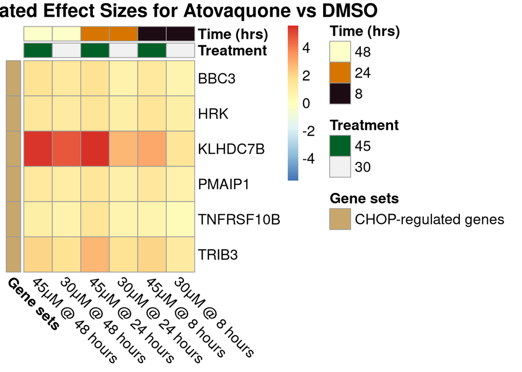

And then a barplot.

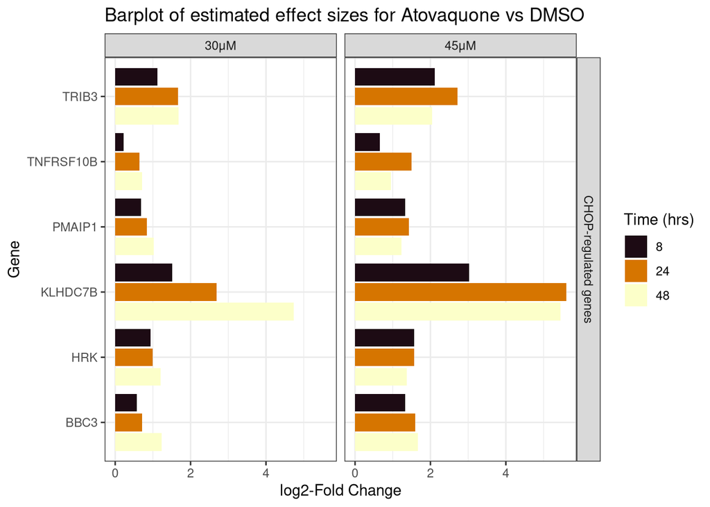

## Natural killer cell ligands

This super category is defined by the sub-categories as

```
## $`Natural killer cell ligands`
## [1] "MICB"  "ULBP1" "ULBP2"
```

First we plot a heatmap.

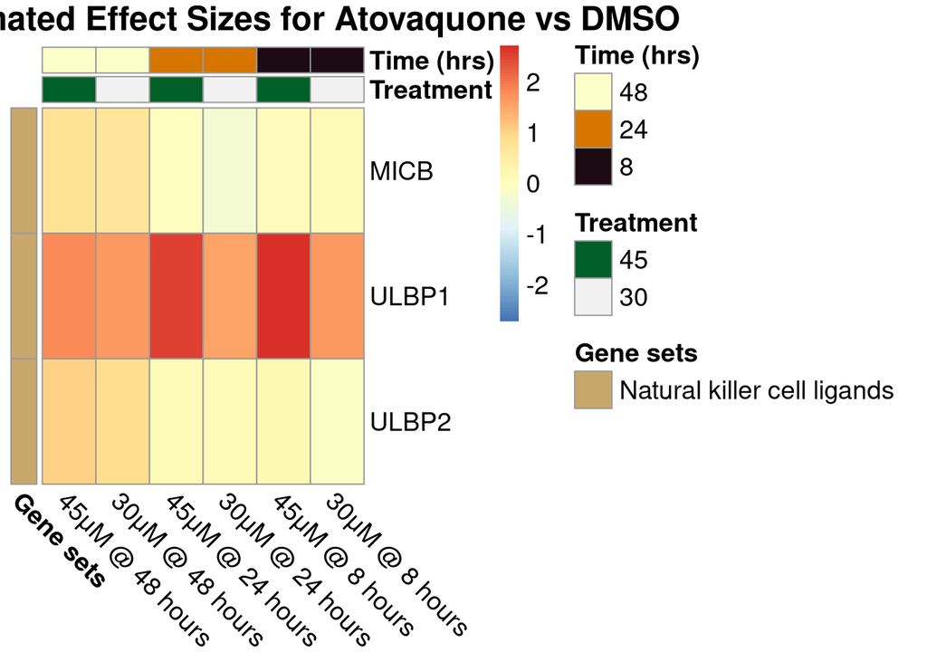

And then a barplot.

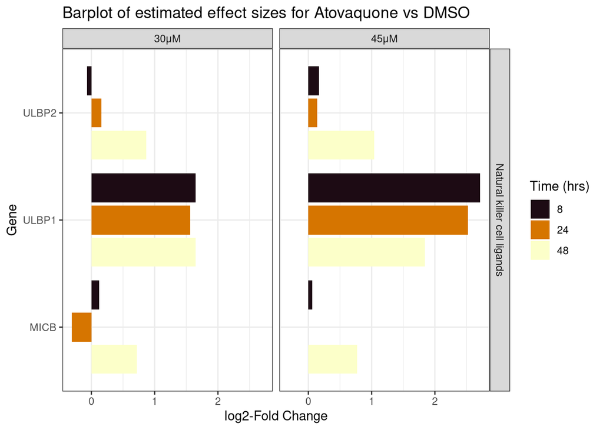

## Immune-related genes

This super category is defined by the sub-categories as

```
## $Chemokines
## [1] "CXCL8"  "CXCL16" "CXCL10"
##
## $`Death receptors`
## [1] "TNFRSF10A" "TNFRSF10B"
```

First we plot a heatmap.

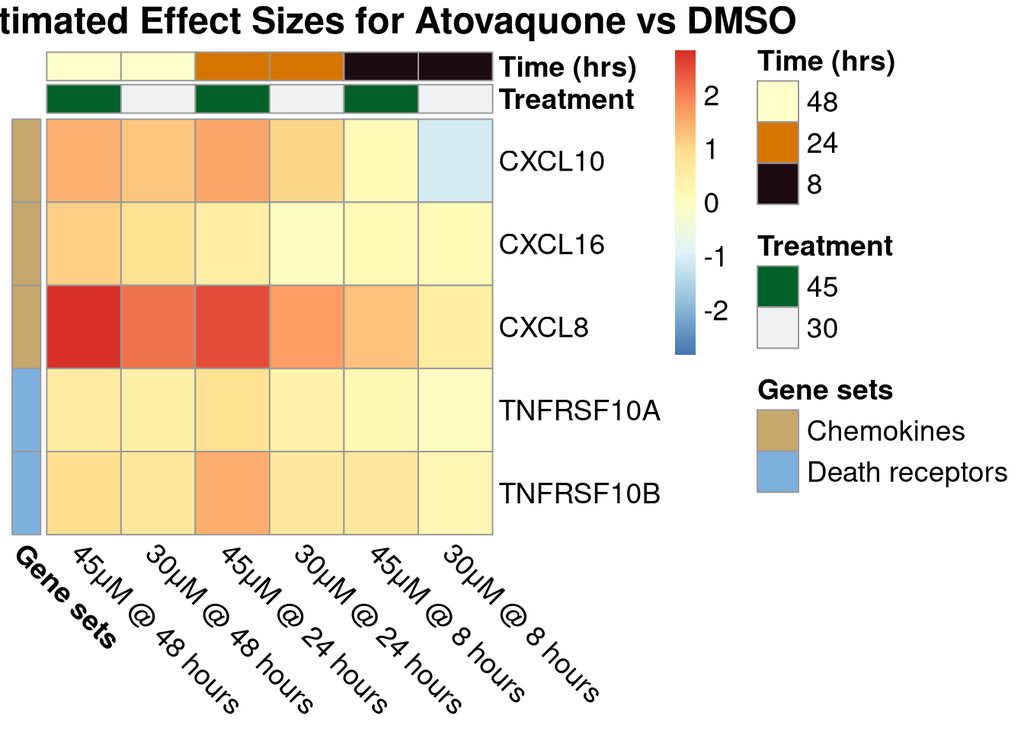

And then a barplot.

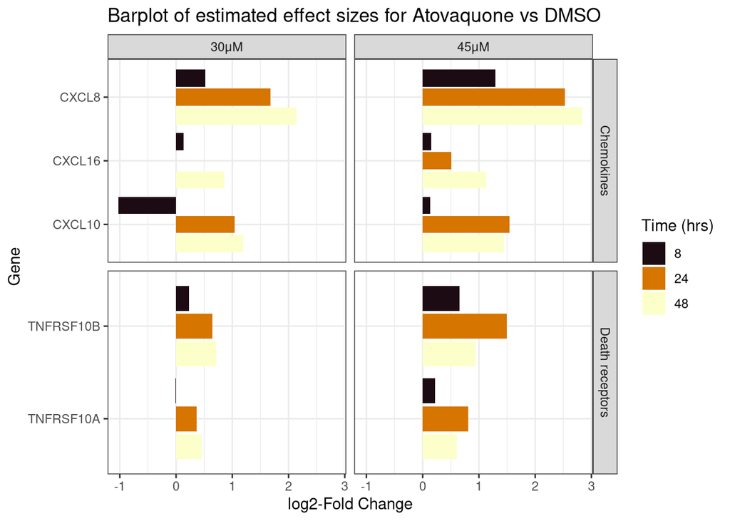